# A Test of the Stroop Effect

Zexin Xia

March 01, 2017

### Introduction

The Stroop effect is a psychological occurrence named after American psychologist, [John Ridley Stroop](https://en.wikipedia.org/wiki/John_Ridley_Stroop), who describes the effect as a demostration of interference in the reaction time of a task.<sup>[1]</sup> A typical example of such phenomenon can be well demonstrated by the [Interactive Stroop Effect Experiment](https://faculty.washington.edu/chudler/java/ready.html), which is described in detail by the following section.

### The Experiment

Participants are presented with a list of words, with each word displayed in a color of ink. The participant’s task is to say out loud the color of the ink in which the word is printed. The task has two conditions: a congruent words condition, and an incongruent words condition. In the congruent words condition, the words being displayed are color words whose names match the colors in which they are printed: for example RED, BLUE. In the incongruent words condition, the words displayed are color words whose names do not match the colors in which they are printed: for example PURPLE, ORANGE. In each case, the time it takes a participant to name the ink colors in equally-sized lists is measured. Each participant will go through and record a time from each condition.

### The Goal of the Project

According to the Stroop effect, the population of participants in the experiment described above will have a longer reaction time when performing the task under the incongruent words condition than that of the congruent words condition. In other words, if the name of a color is printed in a color that is not denoted by the name, then naming the color of the word would consume more time than if the color of the ink matches the name of the color. The goal of this project is to perform an appropriate statistical test on a sample of participants, who went through the stroop effect experiment and recorded their reaction time of the task under both conditions. Ultimately, the test results will predict the outcome of the entire population of participants who perform the same tasks based on the results of the statistical test and therefore deciding whether the Stroop effect indeed interferes with people’s reaction time of a task.

### Questions For Investigation

**1. What is our independent variable? What is our dependent variable?**

Our independent variable is the condition of Stroop task, and our dependent variable is the time it takes participants to name the colors of ink in seconds.

**2. What is an appropriate set of hypotheses for this task? What kind of statistical test do you expect to perform? Justify your choices.**

Assuming that the population data is approximately normally distribution, and for the reasons listed below, we expect to perform a One Sample Paired t-test, which is carried out when two different treatments are applied to the same subjects.<sup>[2]</sup>

- The variance of the population is unknown.
- The sample size is small (n=24 < 30).
- The same participants are asked to perform the task under both the congruent words condition and the incongruent words condition.

An appropriate set of hypotheses for the task is:

$H_0: \mu_c - \mu_i \geq 0$

$H_a: \mu_c - \mu_i < 0$

The null hypothesis ($H_0$) is that the mean of the population reaction time of the task under the incongruent words condition is not significantly longer than that of the congruent words condition. The alternative hypothesis ($H_a$) is that the mean of the population reaction time of the task under the incongruent words condition is significantly longer than that of the congruent words condition.

**3. Report some descriptive statistics regarding this dataset. Include at least one measure of central tendency and at least one measure of variability.**

[Stroop Effect Dataset](https://drive.google.com/file/d/0B9Yf01UaIbUgQXpYb2NhZ29yX1U/view)

| Participant | Congruent | Incongruent |
| --- | --- | --- |
| 1 | 12.079 | 19.278 |
| 2 | 16.791 | 18.741 |
| 3 | 9.564 | 21.214 |
| 4 | 8.63 | 15.687 |
| 5 | 14.669 | 22.803 |
| 6 | 12.238 | 20.878 |
| 7 | 14.692 | 24.572 |
| 8 | 8.987 | 17.394 |
| 9 | 9.401 | 20.762 |
| 10 | 14.48 | 26.282 |
| 11 | 22.328 | 24.524 |
| 12 | 15.298 | 18.644 |
| 13 | 15.073 | 17.51 |
| 14 | 16.929 | 20.33 |
| 15 | 18.2 | 35.255 |
| 16 | 12.13 | 22.158 |
| 17 | 18.495 | 25.139 |
| 18 | 10.639 | 20.429 |
| 19 | 11.344 | 17.425 |
| 20 | 12.369 | 34.288 |
| 21 | 12.944 | 23.894 |
| 22 | 14.233 | 17.96 |
| 23 | 19.71 | 22.058 |
| 24 | 16.004 | 21.157 |

*Each row of the dataset contains the performance for one participant, with the first number representing their reaction time for the congruent task and the second number representing their reaction time for the incongruent task.

As shown by the R outputs below, the average times of the 24 participants performing the task under the congruent words condition and the incongruent words condition are $\bar{x_c}$=14.05113s and $\bar{x_i}$=22.01592s respectively. The sample standard deviations of the two conditions are $s_c$ = 3.559358 and $s_i$ = 4.797057. The difference between the two average times is $\bar{x_c}$ - $\bar{x_i}$=-7.964792s, and the standard deviation of the difference between two conditions in time is $s_d$=4.864827.

```r
stroopdata=read.csv("stroopdata.csv")
# The sample mean of the congruent condition.
AvgCongruent=mean(stroopdata[["Congruent"]])
AvgCongruent
```

```
## [1] 14.05113
```

```r
# The sample mean of the incongruent condition.
AvgIncongruent=mean(stroopdata[["Incongruent"]])
AvgIncongruent
```

```
## [1] 22.01592
```

```r
# The sample standard deviation of the Congruent condition.
sdCongruent=sd(stroopdata[["Congruent"]])
sdCongruent
```

```
## [1] 3.559358
```

```r
# The sample standard deviation of the Incongruent condition.
sdIncongruent=sd(stroopdata[["Incongruent"]])
sdIncongruent
```

```
## [1] 4.797057
```

```r
# The mean difference in time between the two task conditions.
MeanDiff=AvgCongruent-AvgIncongruent
MeanDiff
```

```
## [1] -7.964792
```

```r
# The standard deviation of the difference in time between the two task conditions.
STD.DIFF=sd((stroopdata[["Congruent"]])-(stroopdata[["Incongruent"]]))
STD.DIFF
```

```
## [1] 4.864827
```

**4. Provide one or two visualizations that show the distribution of the sample data. Write one or two sentences noting what you observe about the plot or plots.**

The distribution of the sample data can be visualized with the boxplot shown below. Based on the plot, the reaction time of the task (RTT) under incongruent words condition appears to be longer than that of the congruent words condition, which is consistent with the sample statistics generated earlier. Also,the distribution of the sample data from the Incongruent group is likely to be positively skewed due to two outliners.

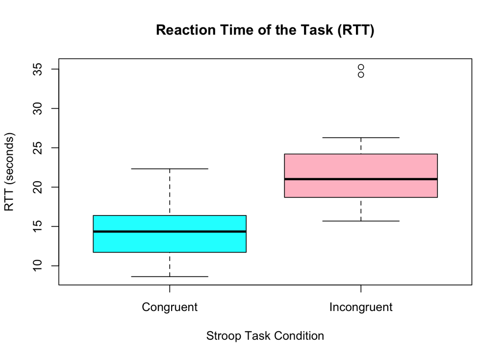

```r
# Boxplot of Reaction Time of the Task (RTT) under the congruent words condition and the incongruent words condition.
boxplot(stroopdata, xlab="Stroop Task Condition", ylab="RTT (seconds)", main="Reaction Time of the Task (RTT)", col=c("cyan","pink"))
```

The distribution of the difference in reaction time of the task between the two sample conditions can be visualized with the Kernel Density Plot shown below. Based on the plot, most of the values (Difference in RTT) that fall under the curve on the x-axis are negative, which again indicates that it is very likely that the reaction time of the task under the incongruent words condition is longer than that of the congruent words condition.

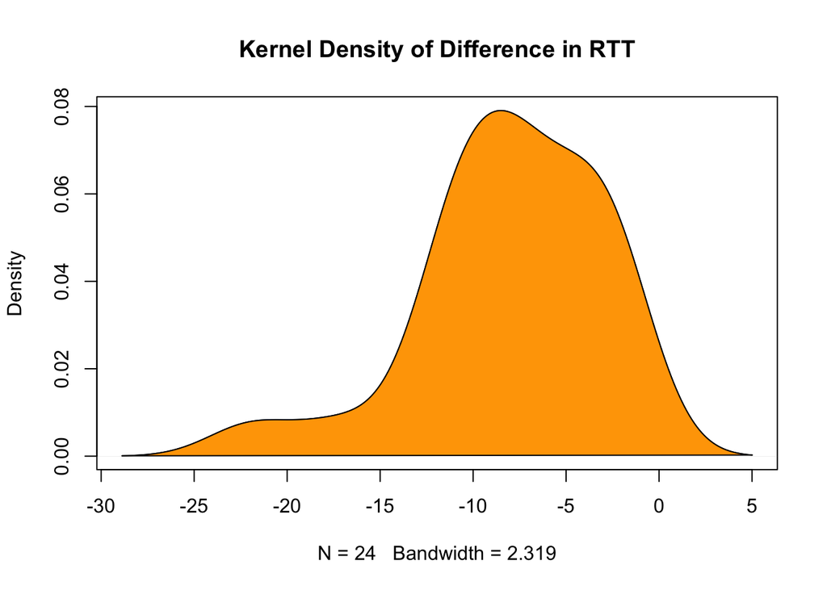

```r
stroopdataD=read.csv("stroopdataD.csv")
diff=density(stroopdataD$D)
plot(diff, main="Kernel Density of Difference in RTT")
polygon(diff, col="orange", border="black")
```

**5. Now, perform the statistical test and report your results. What is your confidence level and your critical statistic value? Do you reject the null hypothesis or fail to reject it? Come to a conclusion in terms of the experiment task. Did the results match up with your expectations?**

```r
# one-sample paired t-test.
Congruent=stroopdataD$Congruent
Incongruent=stroopdataD$Incongruent
t.test(Congruent,Incongruent,paired = TRUE, alternative = "less")
```

```
##
##  Paired t-test
##
## data:  Congruent and Incongruent
## t = -8.0207, df = 23, p-value = 2.052e-08
## alternative hypothesis: true difference in means is less than 0
## 95 percent confidence interval:
##       -Inf -6.262868
## sample estimates:
## mean of the differences
##               -7.964792
```

```r
# Computing the t-critical value.
qt(0.05,23)
```

```
## [1] -1.713872
```

### Conclusion

As shown by the R output above for the one-sample paired t-test, with an $\alpha$ level of 0.05, the t-statistics is equal to -8.0207, which has passed the t-critical value (-1.713872). The p-value is nearly zero, which is less than $\alpha$, and therefore based on both the t-statistic and the p-value of the test, we reject the null hypothesis ($H_0$) in favor of the alternative hypothesis ($H_a$) and conclude that the participants’ reaction time of the task under the incongruent words condition is significantly longer than that of the congruent words condition. The results match up with my expectation as my own result of the stroop effect experiment is consistent with the outcome of this test. In other words, the Stroop effect indeed interferes people’s reaction time of a task.

**6. Optional: What do you think is responsible for the effects observed? Can you think of an alternative or similar task that would result in a similar effect? Some research about the problem will be helpful for thinking about these two questions!**

One plausible explanation for the Stroop effect is that humans tend to read words faster than naming colors of the printed words. In other words, if our task is to name the colors and in the meantime ignoring the printed words, then interference is very likely to result.<sup>[3]</sup> In contrast, if we reverse the process by saying out the printed words and ignoring the colors, then we are likely to react to the task much easier and quicker. A similar task that would result in a similar effect is naming the size of drawings of some real-life objects. For example, say if we present participants with a list of drawings of randomly scaled objects and ask them to say either “big” or “small” to those objects, then they are likely to experience the Stroop effect if they see a drawing of an elephant, for example, that looks as small as a rabbit.

### References

1. Wikipedia, https://en.wikipedia.org/wiki/Stroop_effect. Retrieved 2017-02-28
2. Lund Research Ltd. “[Paired t-test using Stata](https://statistics.laerd.com/stata-tutorials/paired-t-test-using-stata.php)”. statistics.laerd.com. Retrieved 2017-02-27.
3. Macleod, M. Colin, “[The Stroop effect](http://imbs.uci.edu/~kjameson/ECST/MacLeod_TheStroopEffect.pdf)”,Encyclopedia of Color Science and Technology,1,2015.